# DATA PROCESSING AND VISUALIZATION PROJECT

## by Viktor Dominhes

### Project theme

You are planning to watch a movie. Can you trust online movie ratings and reviews? Especially if the company that deals with ratings and reviews also makes money selling movie tickets. Do these companies tend to over- or under-rate?

### The goal of the project:

The goal of the project is to follow the steps in the fivethirtyeight.com article on ratings and see if we can come to the same conclusions as in the article in order to determine if Fandango provided inflated ratings in 2015 in order to increase sales. To achieve the goal of the project, Python libraries will be used for working with data: NumPy, Pandas, as well as for data visualization: Matplotlib, Seaborn.

## Part 1: Explore the data

Objective: to study the article on which our project is based: "Be Suspicious Of Online Movie Ratings, Especially Fandango's"

The source data for [Be Suspicious Of Online Movie Ratings, Especially Fandango’s](http://fivethirtyeight.com/features/fandango-movies-ratings/) is freely available at the following github link: https://github.com/fivethirtyeight/data. These are two csv files. One file contains rating data from Fandango, and the other file contains aggregated rating data from other companies such as Metacritic, IMDB, and Rotten Tomatoes.

The `all_sites_scores.csv` file contains all films that have a Rotten Tomatoes rating, an RT User rating, a Metacritic rating, a Metacritic User rating, and an IMDb rating, and at least 30 Fandango fan reviews. The Fandango data was uploaded on August 24, 2015.

| Column | Definition |
| --- | --- |
| FILMS | Movie title |
| Rotten Tomatoes | Rotten Tomatoes Tomatometer rating for this movie |
| RottenTomatoes_User | Rotten Tomatoes user rating for this movie |
| Metacritic | Metacritic rating for this movie |
| Metacritic_User | Metacritic user rating for this movie |
| IMDB | "IMDb user" rating for this movie |
| Metacritic_user_vote_count | The number of votes for this movie from Metacritic users |
| IMDB_user_vote_count | Number of votes for this movie from IMDb users |

The file `fandango_scrape.csv` contains data about the films that the authors of the article downloaded from Fandango.

| Column | Definition |
| --- | --- |
| FILMS | Movie title |
| STARS | Number of stars on Fandango.com |
| RATING | The Fandango rating is the value read from the HTML page. This is an average rating for a movie. |
| VOTES | The number of votes of users who wrote a review about the film (at the time of uploading the data). |

## Part 2: Compare Fandango Ratings with Other User Ratings

First, let's look at Fandango's ratings and see if the results of our analysis agree with the findings in the article.

```python
# import the necessary libraries for working with data
import pandas as pd
import numpy as np
import seaborn as sns
import matplotlib.pyplot as plt
```

```python
#upload pre-downloaded file "fandango_scrape.csv"
fandango = pd.read_csv("fandango_scrape.csv")
```

Let's examine the properties of the resulting DataFrame object and display the first few lines, as well as general information:

```python
fandango.head()
```

|  | FILM | STARS | RATING | VOTES |
| --- | --- | --- | --- | --- |
| 0 | Fifty Shades of Grey (2015) | 4.0 | 3.9 | 34846 |
| 1 | Jurassic World (2015) | 4.5 | 4.5 | 34390 |
| 2 | American Sniper (2015) | 5.0 | 4.8 | 34085 |
| 3 | Furious 7 (2015) | 5.0 | 4.8 | 33538 |
| 4 | Inside Out (2015) | 4.5 | 4.5 | 15749 |

```python
fandango.info()
```

```
<class 'pandas.core.frame.DataFrame'>
RangeIndex: 504 entries, 0 to 503
Data columns (total 4 columns):
 #   Column  Non-Null Count  Dtype
---  ------  --------------  -----
 0   FILM    504 non-null    object
 1   STARS   504 non-null    float64
 2   RATING  504 non-null    float64
 3   VOTES   504 non-null    int64
dtypes: float64(2), int64(1), object(1)
memory usage: 15.9+ KB
```

```python
fandango.describe()
```

|  | STARS | RATING | VOTES |
| --- | --- | --- | --- |
| count | 504.000000 | 504.000000 | 504.000000 |
| mean | 3.558532 | 3.375794 | 1147.863095 |
| std | 1.563133 | 1.491223 | 3830.583136 |
| min | 0.000000 | 0.000000 | 0.000000 |
| 25% | 3.500000 | 3.100000 | 3.000000 |
| 50% | 4.000000 | 3.800000 | 18.500000 |
| 75% | 4.500000 | 4.300000 | 189.750000 |
| max | 5.000000 | 5.000000 | 34846.000000 |

To explore the relationship between a movie's popularity and its rating, let's create a scatterplot that shows the relationship between the RATING and VOTES columns:

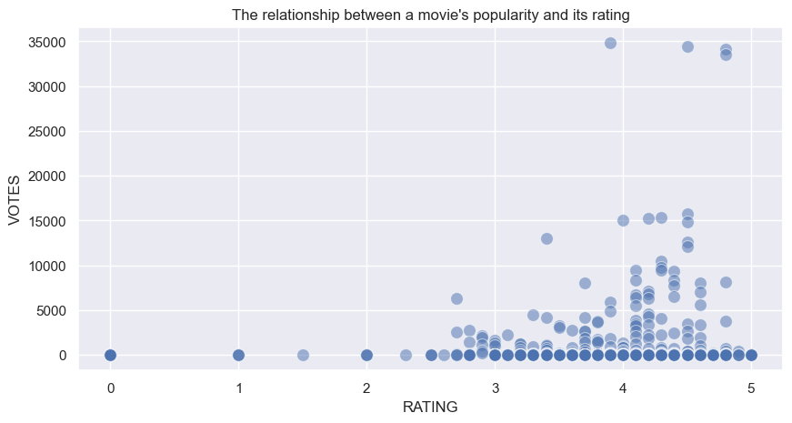

```python
plt.figure(figsize = (10, 5), dpi = 100)
plt.title("The relationship between a movie's popularity and its rating")
sns.scatterplot(data = fandango, x = 'RATING', y = 'VOTES', s = 100, alpha = 0.5);
```

Let's calculate the correlation between the columns:

```python
fandango.corr()
```

|  | STARS | RATING | VOTES |
| --- | --- | --- | --- |
| STARS | 1.000000 | 0.994696 | 0.164218 |
| RATING | 0.994696 | 1.000000 | 0.163764 |
| VOTES | 0.164218 | 0.163764 | 1.000000 |

Let's assume that each row in the FILM column contains a value in the following format: "Movie Title (Year)". Let's create a new column in which we take only the year from the FILM row, and call this new column YEAR:

```python
fandango['YEAR'] = fandango['FILM'].apply(lambda film:film[-5:-1])
```

```python
#look at the new table view
fandango.head()
```

|  | FILM | STARS | RATING | VOTES | YEAR |
| --- | --- | --- | --- | --- | --- |
| 0 | Fifty Shades of Grey (2015) | 4.0 | 3.9 | 34846 | 2015 |
| 1 | Jurassic World (2015) | 4.5 | 4.5 | 34390 | 2015 |
| 2 | American Sniper (2015) | 5.0 | 4.8 | 34085 | 2015 |
| 3 | Furious 7 (2015) | 5.0 | 4.8 | 33538 | 2015 |
| 4 | Inside Out (2015) | 4.5 | 4.5 | 15749 | 2015 |

Find out how many films are in the Fandango dataset, broken down by year:

```python
fandango['YEAR'].value_counts()
```

```
2015    478
2014     23
2012      1
2016      1
1964      1
Name: YEAR, dtype: int64
```

And now we visualize the number of films per year using the countplot graph:

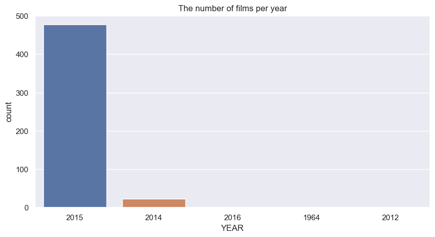

```python
plt.figure(figsize = (10, 5), dpi=100)
plt.title("The number of films per year")
sns.countplot(data = fandango, x = 'YEAR');
```

Next, let's determine which 10 films received the most votes:

```python
fandango.sort_values('VOTES', ascending=False)[:10]
```

|  | FILM | STARS | RATING | VOTES | YEAR |
| --- | --- | --- | --- | --- | --- |
| 0 | Fifty Shades of Grey (2015) | 4.0 | 3.9 | 34846 | 2015 |
| 1 | Jurassic World (2015) | 4.5 | 4.5 | 34390 | 2015 |
| 2 | American Sniper (2015) | 5.0 | 4.8 | 34085 | 2015 |
| 3 | Furious 7 (2015) | 5.0 | 4.8 | 33538 | 2015 |
| 4 | Inside Out (2015) | 4.5 | 4.5 | 15749 | 2015 |
| 5 | The Hobbit: The Battle of the Five Armies (2014) | 4.5 | 4.3 | 15337 | 2014 |
| 6 | Kingsman: The Secret Service (2015) | 4.5 | 4.2 | 15205 | 2015 |
| 7 | Minions (2015) | 4.0 | 4.0 | 14998 | 2015 |
| 8 | Avengers: Age of Ultron (2015) | 5.0 | 4.5 | 14846 | 2015 |
| 9 | Into the Woods (2014) | 3.5 | 3.4 | 13055 | 2014 |

And also find out how many films have zero votes (votes):

```python
len(fandango[fandango['VOTES'] == 0])
```

```
69
```

For the correctness of further research, we will create a new DataFrame with only those films that have votes (votes) - that is, we will delete those films that do not have any votes:

```python
is_votes_fandango = fandango[fandango['VOTES'] != 0]
```

```python
#Let's look at the new DataFrame
is_votes_fandango
```

|  | FILM | STARS | RATING | VOTES | YEAR |
| --- | --- | --- | --- | --- | --- |
| 0 | Fifty Shades of Grey (2015) | 4.0 | 3.9 | 34846 | 2015 |
| 1 | Jurassic World (2015) | 4.5 | 4.5 | 34390 | 2015 |
| 2 | American Sniper (2015) | 5.0 | 4.8 | 34085 | 2015 |
| 3 | Furious 7 (2015) | 5.0 | 4.8 | 33538 | 2015 |
| 4 | Inside Out (2015) | 4.5 | 4.5 | 15749 | 2015 |
| ... | ... | ... | ... | ... | ... |
| 430 | That Sugar Film (2015) | 5.0 | 5.0 | 1 | 2015 |
| 431 | The Intern (2015) | 5.0 | 5.0 | 1 | 2015 |
| 432 | The Park Bench (2015) | 5.0 | 5.0 | 1 | 2015 |
| 433 | The Wanted 18 (2015) | 5.0 | 5.0 | 1 | 2015 |
| 434 | Z For Zachariah (2015) | 5.0 | 5.0 | 1 | 2015 |

435 rows × 5 columns

Due to the way star ratings are displayed on HTML pages, the actual user ratings may differ slightly from the ratings that are shown to the user. Let's visualize this distribution difference.

Let's create a KDE plot (or several such plots) that plots the distribution of displayed ratings (STARS) and true ratings based on user votes (RATING). We will cut the KDE range within 0-5:

[figure not shown]

```python
plt.figure(figsize = (10, 5), dpi = 100)
sns.kdeplot(data=is_votes_fandango, x='RATING',clip=[0,5], bw_adjust=1, shade=True, color='blue', label= 'Stars Displated')
sns.kdeplot(data=is_votes_fandango, x='STARS',clip=[0,5], bw_adjust=1, shade=True, color='red', label= 'True Rating')
plt.title("The distribution of displayed ratings (STARS) and true ratings based on user votes (RATING)")
plt.legend(loc=(0.02,0.85));
```

We also calculate this difference in numerical form. To do this, we will create a new column in which we store the difference between the STARS and RATING columns, and also round to one decimal digit after the decimal point:

```python
is_votes_fandango['STARS_DIFF'] = round((is_votes_fandango['STARS'] - is_votes_fandango['RATING']), 1);
```

```python
#let's look at the result
is_votes_fandango
```

|  | FILM | STARS | RATING | VOTES | YEAR | STARS_DIFF |
| --- | --- | --- | --- | --- | --- | --- |
| 0 | Fifty Shades of Grey (2015) | 4.0 | 3.9 | 34846 | 2015 | 0.1 |
| 1 | Jurassic World (2015) | 4.5 | 4.5 | 34390 | 2015 | 0.0 |
| 2 | American Sniper (2015) | 5.0 | 4.8 | 34085 | 2015 | 0.2 |
| 3 | Furious 7 (2015) | 5.0 | 4.8 | 33538 | 2015 | 0.2 |
| 4 | Inside Out (2015) | 4.5 | 4.5 | 15749 | 2015 | 0.0 |
| ... | ... | ... | ... | ... | ... | ... |
| 430 | That Sugar Film (2015) | 5.0 | 5.0 | 1 | 2015 | 0.0 |
| 431 | The Intern (2015) | 5.0 | 5.0 | 1 | 2015 | 0.0 |
| 432 | The Park Bench (2015) | 5.0 | 5.0 | 1 | 2015 | 0.0 |
| 433 | The Wanted 18 (2015) | 5.0 | 5.0 | 1 | 2015 | 0.0 |
| 434 | Z For Zachariah (2015) | 5.0 | 5.0 | 1 | 2015 | 0.0 |

435 rows × 6 columns

Let's find out how many times this or that value of the difference between STAR and RATING occurs. To do this, let's create a countplot chart:

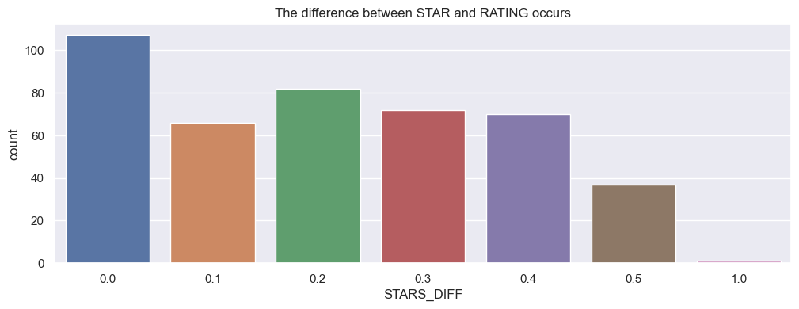

```python
plt.figure(figsize = (12,4), dpi=100)
plt.title("The difference between STAR and RATING occurs")
sns.countplot(data = is_votes_fandango, x = 'STARS_DIFF');
```

In this graph, we can see that one of the movies has a 1 star difference between the displayed rating and the true rating. Let's find this movie:

```python
is_votes_fandango.loc[is_votes_fandango['STARS_DIFF'] == 1.0]
```

|  | FILM | STARS | RATING | VOTES | YEAR | STARS_DIFF |
| --- | --- | --- | --- | --- | --- | --- |
| 381 | Turbo Kid (2015) | 5.0 | 4.0 | 2 | 2015 | 1.0 |

## Part 3: Comparison of Fandango's ratings with those of other companies.

Let's see how Fandango's ratings compare to those of other companies.

```python
#upload the file "all_sites_scores.csv"
all_sites = pd.read_csv("all_sites_scores.csv")
```

Let's examine the general properties of the resulting DataFrame object:

```python
all_sites.head()
```

|  | FILM | RottenTomatoes | RottenTomatoes_User | Metacritic | Metacritic_User | IMDB | Metacritic_user_vote_count | IMDB_user_vote_count |
| --- | --- | --- | --- | --- | --- | --- | --- | --- |
| 0 | Avengers: Age of Ultron (2015) | 74 | 86 | 66 | 7.1 | 7.8 | 1330 | 271107 |
| 1 | Cinderella (2015) | 85 | 80 | 67 | 7.5 | 7.1 | 249 | 65709 |
| 2 | Ant-Man (2015) | 80 | 90 | 64 | 8.1 | 7.8 | 627 | 103660 |
| 3 | Do You Believe? (2015) | 18 | 84 | 22 | 4.7 | 5.4 | 31 | 3136 |
| 4 | Hot Tub Time Machine 2 (2015) | 14 | 28 | 29 | 3.4 | 5.1 | 88 | 19560 |

```python
all_sites.info()
```

```
<class 'pandas.core.frame.DataFrame'>
RangeIndex: 146 entries, 0 to 145
Data columns (total 8 columns):
 #   Column                      Non-Null Count  Dtype
---  ------                      --------------  -----
 0   FILM                        146 non-null    object
 1   RottenTomatoes              146 non-null    int64
 2   RottenTomatoes_User         146 non-null    int64
 3   Metacritic                  146 non-null    int64
 4   Metacritic_User             146 non-null    float64
 5   IMDB                        146 non-null    float64
 6   Metacritic_user_vote_count  146 non-null    int64
 7   IMDB_user_vote_count        146 non-null    int64
dtypes: float64(2), int64(5), object(1)
memory usage: 9.2+ KB
```

```python
all_sites.describe()
```

|  | RottenTomatoes | RottenTomatoes_User | Metacritic | Metacritic_User | IMDB | Metacritic_user_vote_count | IMDB_user_vote_count |
| --- | --- | --- | --- | --- | --- | --- | --- |
| count | 146.000000 | 146.000000 | 146.000000 | 146.000000 | 146.000000 | 146.000000 | 146.000000 |
| mean | 60.849315 | 63.876712 | 58.808219 | 6.519178 | 6.736986 | 185.705479 | 42846.205479 |
| std | 30.168799 | 20.024430 | 19.517389 | 1.510712 | 0.958736 | 316.606515 | 67406.509171 |
| min | 5.000000 | 20.000000 | 13.000000 | 2.400000 | 4.000000 | 4.000000 | 243.000000 |
| 25% | 31.250000 | 50.000000 | 43.500000 | 5.700000 | 6.300000 | 33.250000 | 5627.000000 |
| 50% | 63.500000 | 66.500000 | 59.000000 | 6.850000 | 6.900000 | 72.500000 | 19103.000000 |
| 75% | 89.000000 | 81.000000 | 75.000000 | 7.500000 | 7.400000 | 168.500000 | 45185.750000 |
| max | 100.000000 | 94.000000 | 94.000000 | 9.600000 | 8.600000 | 2375.000000 | 334164.000000 |

Let's start with the Rotten Tomatoes ratings. There are two sets of ratings here - ratings published by official critics and user ratings.

First, let's draw a scatterplot plot for Rotten Tomatoes the relationship between critic ratings and user ratings.

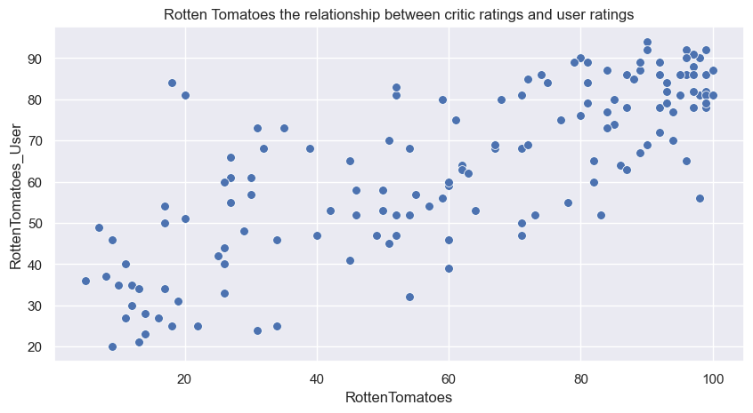

```python
plt.figure(figsize = (10, 5), dpi = 100)
sns.set(style='darkgrid')
plt.title("Rotten Tomatoes the relationship between critic ratings and user ratings")
sns.scatterplot(data = all_sites, x = 'RottenTomatoes', y = 'RottenTomatoes_User', s = 50, alpha = 1);
```

Let's examine the numerical difference between these two ratings. Let's calculate this difference using the RottenTomatoes-RottenTomatoes_User formula. The resulting Rotten_Diff values are the critic rating minus the user rating. Values close to zero indicate that critics and users agree with each other. Large positive values - when critics rated the film much higher than users. And large negative values - on the contrary, users rated the film much higher than critics.

Let's create a new column that stores the difference between the critics rating and the user rating for Rotten Tomatoes:

```python
all_sites['Rotten_Diff'] = all_sites['RottenTomatoes'] - all_sites['RottenTomatoes_User']
```

```python
#let's look at the result
all_sites
```

|  | FILM | RottenTomatoes | RottenTomatoes_User | Metacritic | Metacritic_User | IMDB | Metacritic_user_vote_count | IMDB_user_vote_count | Rotten_Diff |
| --- | --- | --- | --- | --- | --- | --- | --- | --- | --- |
| 0 | Avengers: Age of Ultron (2015) | 74 | 86 | 66 | 7.1 | 7.8 | 1330 | 271107 | -12 |
| 1 | Cinderella (2015) | 85 | 80 | 67 | 7.5 | 7.1 | 249 | 65709 | 5 |
| 2 | Ant-Man (2015) | 80 | 90 | 64 | 8.1 | 7.8 | 627 | 103660 | -10 |
| 3 | Do You Believe? (2015) | 18 | 84 | 22 | 4.7 | 5.4 | 31 | 3136 | -66 |
| 4 | Hot Tub Time Machine 2 (2015) | 14 | 28 | 29 | 3.4 | 5.1 | 88 | 19560 | -14 |
| ... | ... | ... | ... | ... | ... | ... | ... | ... | ... |
| 141 | Mr. Holmes (2015) | 87 | 78 | 67 | 7.9 | 7.4 | 33 | 7367 | 9 |
| 142 | '71 (2015) | 97 | 82 | 83 | 7.5 | 7.2 | 60 | 24116 | 15 |
| 143 | Two Days, One Night (2014) | 97 | 78 | 89 | 8.8 | 7.4 | 123 | 24345 | 19 |
| 144 | Gett: The Trial of Viviane Amsalem (2015) | 100 | 81 | 90 | 7.3 | 7.8 | 19 | 1955 | 19 |
| 145 | Kumiko, The Treasure Hunter (2015) | 87 | 63 | 68 | 6.4 | 6.7 | 19 | 5289 | 24 |

146 rows × 9 columns

Now let's calculate the average value of the obtained difference over the entire data set. Since the difference can be both positive and negative, we first take the absolute values of all values, and only after that we calculate the average value. This way we will get the average of the absolute difference between the ratings from critics and user ratings:

```python
np.abs(all_sites['Rotten_Diff']).mean()
```

```
15.095890410958905
```

Let's plot the distribution of the difference between critic and user ratings for Rotten Tomatoes. This graph will show negative values. To display this distribution, we use both KDE and a histogram:

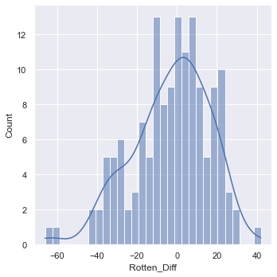

```python
plt.figure(figsize = (10, 5), dpi = 100)
sns.displot(data = all_sites, x = 'Rotten_Diff', kde = True, bins = 30);
```

As well as a graph of the distribution of the absolute values of the difference between ratings from critics and user ratings for Rotten Tomatoes.

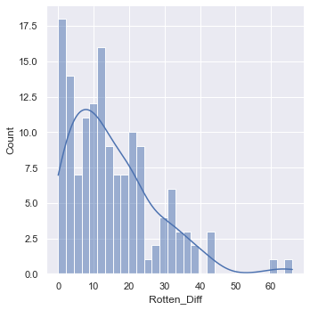

```python
plt.figure(figsize = (10, 5), dpi = 100)
sns.displot(data = all_sites, x = np.abs(all_sites['Rotten_Diff']), kde = True, bins = 30);
```

Let's find out which films differ the most in ratings. First print 5 movies with the biggest negative rating difference modulo. Since we calculated the difference in ratings using the Critics Rating - Users Rating formula, large negative values in modulus indicate that users, on average, rated these films much higher than critics.

1) Users Love but Critics Hate:

```python
all_sites.sort_values('Rotten_Diff', ascending=True)[['FILM','Rotten_Diff']][:5]
```

|  | FILM | Rotten_Diff |
| --- | --- | --- |
| 3 | Do You Believe? (2015) | -66 |
| 85 | Little Boy (2015) | -61 |
| 134 | The Longest Ride (2015) | -42 |
| 105 | Hitman: Agent 47 (2015) | -42 |
| 125 | The Wedding Ringer (2015) | -39 |

2) Critics love, but Users Hate:

```python
all_sites.sort_values('Rotten_Diff', ascending=False)[['FILM','Rotten_Diff']][:5]
```

|  | FILM | Rotten_Diff |
| --- | --- | --- |
| 69 | Mr. Turner (2014) | 42 |
| 112 | It Follows (2015) | 31 |
| 115 | While We're Young (2015) | 31 |
| 145 | Kumiko, The Treasure Hunter (2015) | 24 |
| 37 | Welcome to Me (2015) | 24 |

#### Ratings from MetaCritic

Next, let's take a quick look at the ratings from MetaCritic. They also display two types of ratings - both their official ratings and user ratings.

Let's draw a scatterplot to compare Metacritic and Metacritic User ratings:

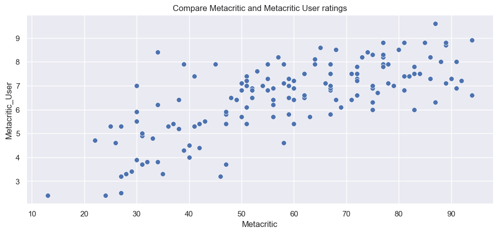

```python
plt.figure(figsize = (12, 5), dpi = 100)
plt.title("Compare Metacritic and Metacritic User ratings")
sns.scatterplot(data = all_sites, x = 'Metacritic', y = 'Metacritic_User', s = 50, alpha = 1);
```

#### Ratings from IMDB

And finally, let's look at the ratings from IMDB. Please note that Metacritic and IMDB show the number of votes. Let's look at the most popular films.

Let's draw a scatterplot to show the relationship between the number of votes on MetaCritic and the number of votes on IMDB:

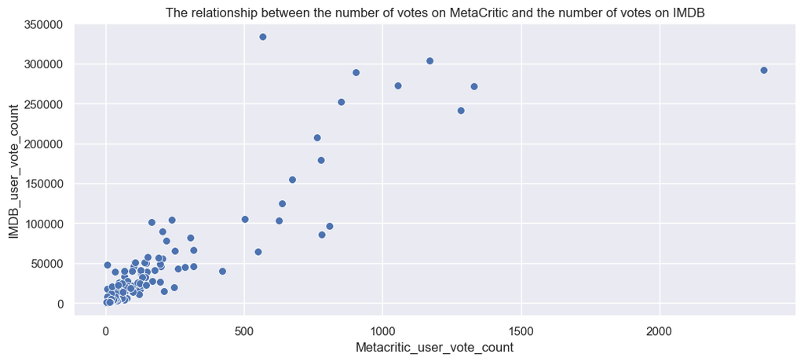

```python
plt.figure(figsize = (12, 5), dpi = 100)
plt.title("The relationship between the number of votes on MetaCritic and the number of votes on IMDB")
sns.scatterplot(data = all_sites, x = 'Metacritic_user_vote_count', y = 'IMDB_user_vote_count', s = 50, alpha = 1);
```

Here we see two "outliers" - points that are very different from all other points. One film received the most votes on IMDB, but only 500 votes on Metacritic. What is this movie?

```python
all_sites.sort_values('IMDB_user_vote_count',ascending=False)[:1]
```

|  | FILM | RottenTomatoes | RottenTomatoes_User | Metacritic | Metacritic_User | IMDB | Metacritic_user_vote_count | IMDB_user_vote_count | Rotten_Diff |
| --- | --- | --- | --- | --- | --- | --- | --- | --- | --- |
| 14 | The Imitation Game (2014) | 90 | 92 | 73 | 8.2 | 8.1 | 566 | 334164 | -2 |

Let's also see which movie received the most votes on Metacritic:

```python
all_sites.sort_values('Metacritic_user_vote_count',ascending=False)[:1]
```

|  | FILM | RottenTomatoes | RottenTomatoes_User | Metacritic | Metacritic_User | IMDB | Metacritic_user_vote_count | IMDB_user_vote_count | Rotten_Diff |
| --- | --- | --- | --- | --- | --- | --- | --- | --- | --- |
| 88 | Mad Max: Fury Road (2015) | 97 | 88 | 89 | 8.7 | 8.3 | 2375 | 292023 | 9 |

### Let's finally find out if Fandango's ratings were artificially high in order to sell more tickets.

To do this, join the fandango table with the all_sites table. Not every movie in the Fandango table will be in the all_sites table because some Fandango movies have very few or no reviews. But we want to compare only those films that are in both tables. So let's do an "inner merge" of the two datasets, matching the rows on the FILM column:

```python
all_sites = is_votes_fandango.drop('STARS_DIFF', axis = 1).merge(all_sites, how='inner')
```

```python
all_sites.head()
```

|  | FILM | STARS | RATING | VOTES | YEAR | RottenTomatoes | RottenTomatoes_User | Metacritic | Metacritic_User | IMDB | Metacritic_user_vote_count | IMDB_user_vote_count | Rotten_Diff |
| --- | --- | --- | --- | --- | --- | --- | --- | --- | --- | --- | --- | --- | --- |
| 0 | Fifty Shades of Grey (2015) | 4.0 | 3.9 | 34846 | 2015 | 25 | 42 | 46 | 3.2 | 4.2 | 778 | 179506 | -17 |
| 1 | Jurassic World (2015) | 4.5 | 4.5 | 34390 | 2015 | 71 | 81 | 59 | 7.0 | 7.3 | 1281 | 241807 | -10 |
| 2 | American Sniper (2015) | 5.0 | 4.8 | 34085 | 2015 | 72 | 85 | 72 | 6.6 | 7.4 | 850 | 251856 | -13 |
| 3 | Furious 7 (2015) | 5.0 | 4.8 | 33538 | 2015 | 81 | 84 | 67 | 6.8 | 7.4 | 764 | 207211 | -3 |
| 4 | Inside Out (2015) | 4.5 | 4.5 | 15749 | 2015 | 98 | 90 | 94 | 8.9 | 8.6 | 807 | 96252 | 8 |

Note that Rotten Tomatoes, Metacritic, and IMDB use a different rating scale than Fandango's 0 to 5 star scale. In order to make comparisons correctly, we need to normalize these values so that they fall within the range of 0 to 5 stars. To do this, let's add additional columns to DataFrame all_sites, and write normalized rating values from 0 to 5 in them:

```python
all_sites['RT_Norm'] = round(all_sites['RottenTomatoes'] / 20, 1)
all_sites['RTU_Norm'] = round(all_sites['RottenTomatoes_User'] / 20, 1)
all_sites['Meta_Norm'] = round(all_sites['Metacritic'] / 20, 1)
all_sites['Meta_U_Norm'] = round(all_sites['Metacritic_User'] / 2, 1)
all_sites['IMDB_Norm'] = round(all_sites['IMDB'] / 2, 1)
```

```python
#check the result
all_sites.head()
```

|  | FILM | STARS | RATING | VOTES | YEAR | RottenTomatoes | RottenTomatoes_User | Metacritic | Metacritic_User | IMDB | Metacritic_user_vote_count | IMDB_user_vote_count | Rotten_Diff | RT_Norm | RTU_Norm | Meta_Norm | Meta_U_Norm | IMDB_Norm |
| --- | --- | --- | --- | --- | --- | --- | --- | --- | --- | --- | --- | --- | --- | --- | --- | --- | --- | --- |
| 0 | Fifty Shades of Grey (2015) | 4.0 | 3.9 | 34846 | 2015 | 25 | 42 | 46 | 3.2 | 4.2 | 778 | 179506 | -17 | 1.2 | 2.1 | 2.3 | 1.6 | 2.1 |
| 1 | Jurassic World (2015) | 4.5 | 4.5 | 34390 | 2015 | 71 | 81 | 59 | 7.0 | 7.3 | 1281 | 241807 | -10 | 3.6 | 4.0 | 3.0 | 3.5 | 3.6 |
| 2 | American Sniper (2015) | 5.0 | 4.8 | 34085 | 2015 | 72 | 85 | 72 | 6.6 | 7.4 | 850 | 251856 | -13 | 3.6 | 4.2 | 3.6 | 3.3 | 3.7 |
| 3 | Furious 7 (2015) | 5.0 | 4.8 | 33538 | 2015 | 81 | 84 | 67 | 6.8 | 7.4 | 764 | 207211 | -3 | 4.0 | 4.2 | 3.4 | 3.4 | 3.7 |
| 4 | Inside Out (2015) | 4.5 | 4.5 | 15749 | 2015 | 98 | 90 | 94 | 8.9 | 8.6 | 807 | 96252 | 8 | 4.9 | 4.5 | 4.7 | 4.4 | 4.3 |

Next, we will create a DataFrame called norm_scores, in which we will leave only normalized ratings. We will also leave the STARS and RATING columns from the original fandango table:

```python
norm_scores = all_sites.drop(['FILM', 'RottenTomatoes', 'RottenTomatoes_User', 'Metacritic', 'Metacritic_User', 'IMDB', 'VOTES', 'YEAR', 'Metacritic_user_vote_count', 'IMDB_user_vote_count', 'Rotten_Diff'], axis = 1)
```

```python
#check the result
norm_scores.head()
```

|  | STARS | RATING | RT_Norm | RTU_Norm | Meta_Norm | Meta_U_Norm | IMDB_Norm |
| --- | --- | --- | --- | --- | --- | --- | --- |
| 0 | 4.0 | 3.9 | 1.2 | 2.1 | 2.3 | 1.6 | 2.1 |
| 1 | 4.5 | 4.5 | 3.6 | 4.0 | 3.0 | 3.5 | 3.6 |
| 2 | 5.0 | 4.8 | 3.6 | 4.2 | 3.6 | 3.3 | 3.7 |
| 3 | 5.0 | 4.8 | 4.0 | 4.2 | 3.4 | 3.4 | 3.7 |
| 4 | 4.5 | 4.5 | 4.9 | 4.5 | 4.7 | 4.4 | 4.3 |

Let's draw a graph comparing the distributions of normalized ratings from all companies:

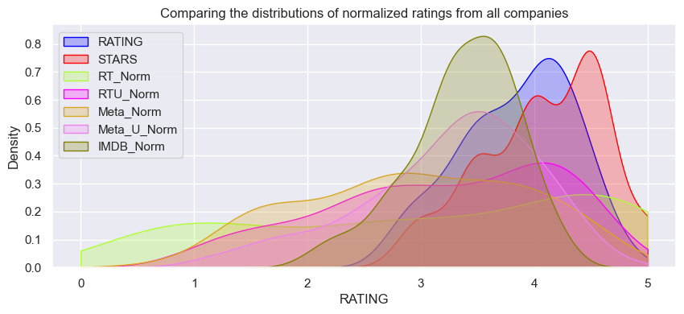

```python
plt.figure(figsize = (10, 4), dpi = 100)
sns.kdeplot(data=norm_scores, x='RATING',clip=[0,5], shade=True, color='blue', label= 'RATING')
sns.kdeplot(data=norm_scores, x='STARS',clip=[0,5], shade=True, color='red', label= 'STARS')
sns.kdeplot(data=norm_scores, x='RT_Norm',clip=[0,5], shade=True, color='#ADFF2F', label= 'RT_Norm')
sns.kdeplot(data=norm_scores, x='RTU_Norm',clip=[0,5], shade=True, color='#FF00FF', label= 'RTU_Norm')
sns.kdeplot(data=norm_scores, x='Meta_Norm',clip=[0,5], shade=True, color='#DAA520', label= 'Meta_Norm')
sns.kdeplot(data=norm_scores, x='Meta_U_Norm',clip=[0,5], shade=True, color='violet', label= 'Meta_U_Norm')
sns.kdeplot(data=norm_scores, x='IMDB_Norm',clip=[0,5], shade=True, color='#808000', label= 'IMDB_Norm')
plt.legend(loc=(0.01,0.45))
plt.title("Comparing the distributions of normalized ratings from all companies");
```

We immediately see that Fandango's ratings are very shifted to the right. It is also interesting that RT ratings from critics have a very flat distribution. Let's compare only these two distributions.

Let's draw a KDE plot comparing the distribution of Rotten Tomatoes ratings from critics and the distribution of STARS ratings from Fandango:

[figure not shown]

```python
plt.figure(figsize = (10, 4), dpi = 100)
sns.kdeplot(data=norm_scores, x='STARS',clip=[0,5], shade=True, color='red', label= 'STARS')
sns.kdeplot(data=norm_scores, x='RT_Norm',clip=[0,5], shade=True, color='#ADFF2F', label= 'RT_Norm')
plt.legend(loc=(0.01,0.8))
plt.title("Comparing the distribution of Rotten Tomatoes ratings from critics and the distribution of STARS ratings from Fandango");
```

Also, for greater clarity, we will additionally compare all normalized ratings using the histplot graph.

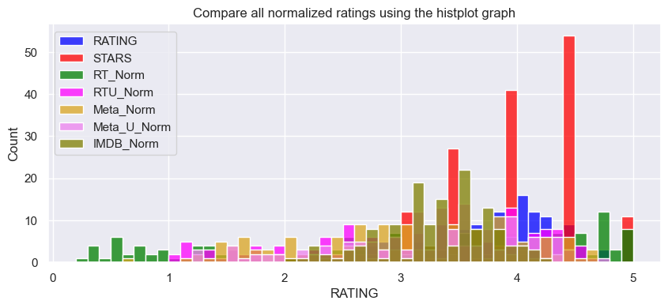

```python
plt.figure(figsize = (10, 4), dpi = 100)
sns.histplot(data=norm_scores, x='RATING', color='blue', label= 'RATING', binwidth=0.1)
sns.histplot(data=norm_scores, x='STARS',color='red', label= 'STARS', binwidth=0.1)
sns.histplot(data=norm_scores, x='RT_Norm', color='Green', label= 'RT_Norm', binwidth=0.1)
sns.histplot(data=norm_scores, x='RTU_Norm', color='#FF00FF', label= 'RTU_Norm', binwidth=0.1)
sns.histplot(data=norm_scores, x='Meta_Norm', color='#DAA520', label= 'Meta_Norm', binwidth=0.1)
sns.histplot(data=norm_scores, x='Meta_U_Norm', color='violet', label= 'Meta_U_Norm', binwidth=0.1)
sns.histplot(data=norm_scores, x='IMDB_Norm', color='#808000', label= 'IMDB_Norm', binwidth=0.1)
plt.legend(loc=(0.01,0.45))
plt.title("Compare all normalized ratings using the histplot graph");
```

Let's determine how different companies rate films with the lowest ratings. To do this, let's draw a clustermap graph for all normalized ratings. Let's pay attention to differences in ratings between different companies. Films with high ratings should fall into one cluster, and films with low ratings into other clusters.

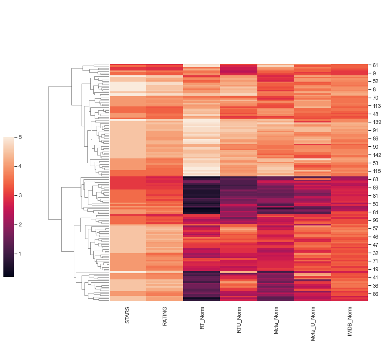

```python
sns.clustermap(norm_scores, col_cluster=False,figsize=(10,10), cbar_pos=(-0.1, .2, .03, .4));
```

We saw that Fandango's ratings are clearly higher than other companies' ratings, especially when looking at the ratings rounded up. Let's now take a look at the top 10 worst rated movies by Rotten Tomatoes Critic - what are those 10 movies? What normalized ratings have other companies given these films?

We need the FILM column, so let's put that column back:

```python
norm_scores['FILM'] = all_sites['FILM']
```

And find the 10 worst-rated films according to Rotten Tomatoes Critic:

```python
ten_worst = norm_scores.sort_values('RT_Norm', ascending=True)[:10]
```

```python
#check the result
ten_worst
```

|  | STARS | RATING | RT_Norm | RTU_Norm | Meta_Norm | Meta_U_Norm | IMDB_Norm | FILM |
| --- | --- | --- | --- | --- | --- | --- | --- | --- |
| 49 | 3.5 | 3.5 | 0.2 | 1.8 | 0.6 | 1.2 | 2.2 | Paul Blart: Mall Cop 2 (2015) |
| 25 | 4.5 | 4.1 | 0.4 | 2.3 | 1.3 | 2.3 | 3.0 | Taken 3 (2015) |
| 28 | 3.0 | 2.7 | 0.4 | 1.0 | 1.4 | 1.2 | 2.0 | Fantastic Four (2015) |
| 84 | 4.0 | 3.9 | 0.4 | 2.4 | 1.4 | 1.6 | 3.0 | Hitman: Agent 47 (2015) |
| 54 | 4.0 | 3.7 | 0.4 | 1.8 | 1.6 | 1.8 | 2.4 | Hot Pursuit (2015) |
| 50 | 4.0 | 3.6 | 0.5 | 1.8 | 1.5 | 2.8 | 2.3 | The Boy Next Door (2015) |
| 109 | 3.0 | 2.9 | 0.6 | 1.0 | 1.8 | 2.7 | 2.3 | The Vatican Tapes (2015) |
| 88 | 4.0 | 3.6 | 0.6 | 2.0 | 1.2 | 1.2 | 3.2 | The Loft (2015) |
| 87 | 3.5 | 3.2 | 0.6 | 1.4 | 1.6 | 1.9 | 2.7 | Unfinished Business (2015) |
| 83 | 3.5 | 3.3 | 0.6 | 1.7 | 1.6 | 2.5 | 2.8 | Sinister 2 (2015) |

And finally visualize the distribution of ratings from all companies for the 10 worst rated films:

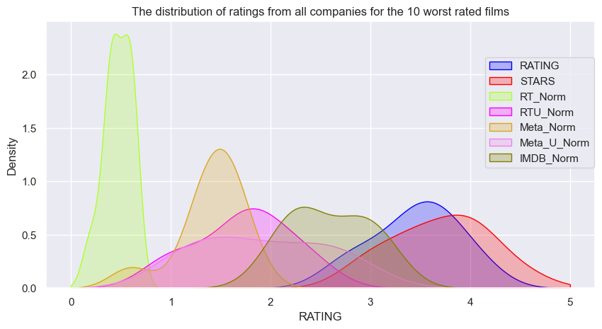

```python
plt.figure(figsize = (10, 5), dpi = 100)
sns.kdeplot(data=ten_worst, x='RATING',clip=[0,5],bw_adjust=1, shade=True, color='blue', label= 'RATING')
sns.kdeplot(data=ten_worst, x='STARS', clip=[0,5],bw_adjust=1, shade=True, color='red', label= 'STARS')
sns.kdeplot(data=ten_worst, x='RT_Norm',clip=[0,5], bw_adjust=1, shade=True, color='#ADFF2F', label= 'RT_Norm')
sns.kdeplot(data=ten_worst, x='RTU_Norm',clip=[0,5],bw_adjust=1, shade=True, color='#FF00FF', label= 'RTU_Norm')
sns.kdeplot(data=ten_worst, x='Meta_Norm',clip=[0,5],bw_adjust=1, shade=True, color='#DAA520', label= 'Meta_Norm')
sns.kdeplot(data=ten_worst, x='Meta_U_Norm',clip=[0,5],bw_adjust=1, shade=True, color='violet', label= 'Meta_U_Norm')
sns.kdeplot(data=ten_worst, x='IMDB_Norm',clip=[0,5],bw_adjust=1, shade=True, color='#808000', label= 'IMDB_Norm')
plt.legend(loc=(0.80,0.45));
plt.title("The distribution of ratings from all companies for the 10 worst rated films");
```

## Conclusion:

**As a result of our research, it was unequivocally established that Fandango showed 3-4 stars for films that were clearly unsuccessful!**

[figure not shown]

**The movie that stands out the most is [Taken 3!](https://www.youtube.com/watch?v=tJrfImRCHJ0) - Fandango gave it a 4.5 star rating, although this movie got an [average rating of 1.86](https://en.wikipedia.org/wiki/Taken_3#Critical_response) from other companies!**

```python
#Film ratings from different companies
norm_scores.iloc[25]
```

```
STARS                     4.5
RATING                    4.1
RT_Norm                   0.4
RTU_Norm                  2.3
Meta_Norm                 1.3
Meta_U_Norm               2.3
IMDB_Norm                   3
FILM           Taken 3 (2015)
Name: 25, dtype: object
```

```python
#Average movie rating from other companies
(0.4+2.3+1.3+2.3+3) / 5
```

```
1.86
```